# RPhaeno Beispiel

Lukas Schefczyk

7 11 2022

## Einführung

Rphaeno soll ein einfaches Tool zum erstellen einer Phaenologie Datenbank sein auf erstmal DWD-Phänologie Datenbasis.

Hier einige Beispiele zur Benutzung:

Einladen der Skripte:

```r
source("load_rphaeno.R")
```

## Datenbank erstellen

Als erstes den Namen der Datenbank definieren

```r
dbname="data/fulldb.sqlite3"
```

Die Datenbank kann entweder aus allen Melderdaten bestehen oder nach ausgewählten Pflanzen.

Die Default-Einstellung der Funktion ist

```r
create_database(dbname=dbname,temp_dir="temp/",
                plant=NULL,downloaddata=TRUE,change_nr_names=FALSE,meta_spezifizierung=TRUE,
                meta_beschreibung=TRUE,keepdldata=TRUE)
```

Sollen nur bestimme Pflanzen berücksichtigt werden, so kann der plant Parameter benutzt werden. Hier kann ein Vektor angegeben werden mit Pflanzen die heruntergeladen werden soll. Bspw. c(“Birne”,“Hasel”). Die Abfrage läuft über str_detect, daher werden bspw. alle Birnen Daten genommen (Birne,Birne_fruehe_Reife,Birne_spaete_Reife). c(“beere”) würde bspw. Brombeere, Himbeere, Erdbeere, Johannisbeere, Rote Johannisbeere, Stachelbeere, Schneebeere herunterladen.

Für weitere Erklärungen der Parameter siehe Readme.md

### Verbinden der Datenbank

```r
con <- DBI::dbConnect(RSQLite::SQLite(), dbname = dbname )
```

## Tabellenliste aus Datenbank auslesen

```r
dbListTables(con)
```

```
##  [1] "Daten_Jahresmelder"
##  [2] "Daten_Sofortmelder"
##  [3] "Mais_Spezifizierung"
##  [4] "Megaframe_Allemelder"
##  [5] "Megaframe_Jahresmelder"
##  [6] "Megaframe_Sofortmelder"
##  [7] "Notizen"
##  [8] "Obst_Spezifizierung"
##  [9] "Pflanze"
## [10] "Phaenologie_Besonderheiten_Zeitreihen"
## [11] "Phaenologie_Qualitaetsbyte"
## [12] "Phaenologie_Qualitaetsniveau"
## [13] "Phase"
## [14] "Phasendefinition"
## [15] "Phasendefinition_Jahresmelder"
## [16] "Phasendefinition_Sofortmelder"
## [17] "Ruebe_Spezifizierung"
## [18] "Spezifizierung_Notizen"
## [19] "Stationen"
## [20] "Stationen_Jahresmelder"
## [21] "Stationen_Sofortmelder"
## [22] "Weinrebe_Spezifizierung"
## [23] "sqlite_stat1"
## [24] "sqlite_stat4"
```

Die Tabellen sind nach den Dateien des DWD benannt und nach Jahresmelder und Sofortmelder getrennt. Die Megaframes sind Views, also aus den Tabellen zusammengesetzte Riesentabelle die aber nur verknüpft sind.

## Tabelle aus Datenbank lesen

Um eine Tabelle aus der Datenbank zu lesen gibt benutzt man folgenden Befehl

```r
Table <- tbl(con,tablename)
```

tbl erstellt aus der Datenbankverbindung con und dem zugehörigen Tabellennamen ein lazy-loaded Tabelle. Erkennbar an den zwei ?? im console output.

```r
megaframe <- tbl(con, "Megaframe_Jahresmelder")
```

```r
megaframe
```

```
## # Source:   table<Megaframe_Jahresmelder> [?? x 26]
## # Database: sqlite 3.35.5 [D:\rphaeno\data\fulldb.sqlite3]
##    stations_id refjahr qualitaetsniveau pflanze_id phase_id eintrittsdatum
##          <int>   <int>            <int>      <int>    <int>          <int>
##  1           3    1953                7        201       25       19530523
##  2           3    1955                7        201       25       19550603
##  3           3    1975               10        201       25       19750607
##  4           3    1976               10        201       25       19760611
##  5           3    1977               10        201       25       19770531
##  6           3    1977               10        201       27       19770806
##  7           3    1978               10        201       25       19780531
##  8           3    1978               10        201       27       19780818
##  9           3    1979               10        201       25       19790609
## 10           3    1979               10        201       27       19790829
## # ... with more rows, and 20 more variables: eintrittsdatum_qb <int>,
## #   jultag <int>, stationsname <chr>, lat <dbl>, lon <dbl>,
## #   stationshoehe <int>, naturraumgruppe_code <int>, naturraumgruppe <chr>,
## #   naturraum_code <int>, naturraum <chr>, datum_stationsaufloesung <chr>,
## #   bundesland <chr>, pflanze <chr>, phase <chr>, phasendefinition <chr>,
## #   bbch_code <int>, hinweis_bbch <chr>, phase_englisch <chr>,
## #   pflanze_englisch <chr>, pflanze_latein <chr>
```

Um Beispielsweise Daten nur für Rheinland-Pfalz zu erhalten und die Blühphase kann filter() verwendet werden:

```r
Daten_rlp <- megaframe %>%
  filter(bundesland %in% c("Rheinland-Pfalz") & phase_id == 5)
```

```r
Daten_rlp
```

```
## # Source:   SQL [?? x 26]
## # Database: sqlite 3.35.5 [D:\rphaeno\data\fulldb.sqlite3]
##    stations_id refjahr qualitaetsniveau pflanze_id phase_id eintrittsdatum
##          <int>   <int>            <int>      <int>    <int>          <int>
##  1        2561    1951                7        233        5       19510618
##  2        2561    1952                7        233        5       19520615
##  3        2561    1953                7        233        5       19530615
##  4        2561    1954                7        233        5       19540625
##  5        2561    1955                7        233        5       19550628
##  6        2561    1956                7        233        5       19560630
##  7        2561    1958                7        233        5       19580624
##  8        2561    1960                7        233        5       19600620
##  9        2561    1961                7        233        5       19610628
## 10        2561    1962                7        233        5       19620628
## # ... with more rows, and 20 more variables: eintrittsdatum_qb <int>,
## #   jultag <int>, stationsname <chr>, lat <dbl>, lon <dbl>,
## #   stationshoehe <int>, naturraumgruppe_code <int>, naturraumgruppe <chr>,
## #   naturraum_code <int>, naturraum <chr>, datum_stationsaufloesung <chr>,
## #   bundesland <chr>, pflanze <chr>, phase <chr>, phasendefinition <chr>,
## #   bbch_code <int>, hinweis_bbch <chr>, phase_englisch <chr>,
## #   pflanze_englisch <chr>, pflanze_latein <chr>
```

Um diese View für Rheinland-Pfalz mit der Blühphase nun als extra View/Tabelle in die Datenbank zu speichern kann man mit

```r
create_view_in_db(df_query,viewname,con=con)
```

dies tun.

```r
create_view_in_db(Daten_rlp,"RLP_Bluehphase_Jahresmelder",con=con)
```

```
## [1] 0
```

```r
dbListTables(con)
```

```
##  [1] "Daten_Jahresmelder"
##  [2] "Daten_Sofortmelder"
##  [3] "Mais_Spezifizierung"
##  [4] "Megaframe_Allemelder"
##  [5] "Megaframe_Jahresmelder"
##  [6] "Megaframe_Sofortmelder"
##  [7] "Notizen"
##  [8] "Obst_Spezifizierung"
##  [9] "Pflanze"
## [10] "Phaenologie_Besonderheiten_Zeitreihen"
## [11] "Phaenologie_Qualitaetsbyte"
## [12] "Phaenologie_Qualitaetsniveau"
## [13] "Phase"
## [14] "Phasendefinition"
## [15] "Phasendefinition_Jahresmelder"
## [16] "Phasendefinition_Sofortmelder"
## [17] "RLP_Bluehphase_Jahresmelder"
## [18] "Ruebe_Spezifizierung"
## [19] "Spezifizierung_Notizen"
## [20] "Stationen"
## [21] "Stationen_Jahresmelder"
## [22] "Stationen_Sofortmelder"
## [23] "Weinrebe_Spezifizierung"
## [24] "sqlite_stat1"
## [25] "sqlite_stat4"
```

Die neu angelegte Tabelle ist nun in der Datenbank, und da als View benötigt diese fast kein Speicherplatz nur Rechen- und HDD-Leistung zum Abruf.

Um eine View zu löschen kann

```r
remove_view_from_db(viewname,con=con)
```

verwendet werden.

```r
remove_view_from_db("RLP_Bluehphase_Jahresmelder",con=con)
```

```
## [1] 0
```

```r
dbListTables(con)
```

```
##  [1] "Daten_Jahresmelder"
##  [2] "Daten_Sofortmelder"
##  [3] "Mais_Spezifizierung"
##  [4] "Megaframe_Allemelder"
##  [5] "Megaframe_Jahresmelder"
##  [6] "Megaframe_Sofortmelder"
##  [7] "Notizen"
##  [8] "Obst_Spezifizierung"
##  [9] "Pflanze"
## [10] "Phaenologie_Besonderheiten_Zeitreihen"
## [11] "Phaenologie_Qualitaetsbyte"
## [12] "Phaenologie_Qualitaetsniveau"
## [13] "Phase"
## [14] "Phasendefinition"
## [15] "Phasendefinition_Jahresmelder"
## [16] "Phasendefinition_Sofortmelder"
## [17] "Ruebe_Spezifizierung"
## [18] "Spezifizierung_Notizen"
## [19] "Stationen"
## [20] "Stationen_Jahresmelder"
## [21] "Stationen_Sofortmelder"
## [22] "Weinrebe_Spezifizierung"
## [23] "sqlite_stat1"
## [24] "sqlite_stat4"
```

Die Daten sind immernoch nur lazy loaded, um sie nun zu erhalten muss die Query abgeschickt werden mit collect()

```r
Daten_rlp <- Daten_rlp %>% collect()
Daten_rlp
```

```
## # A tibble: 386,977 x 26
##    stations_id refjahr qualitaetsniveau pflanze_id phase_id eintrittsdatum
##          <int>   <int>            <int>      <int>    <int>          <int>
##  1        2561    1951                7        233        5       19510618
##  2        2561    1952                7        233        5       19520615
##  3        2561    1953                7        233        5       19530615
##  4        2561    1954                7        233        5       19540625
##  5        2561    1955                7        233        5       19550628
##  6        2561    1956                7        233        5       19560630
##  7        2561    1958                7        233        5       19580624
##  8        2561    1960                7        233        5       19600620
##  9        2561    1961                7        233        5       19610628
## 10        2561    1962                7        233        5       19620628
## # ... with 386,967 more rows, and 20 more variables: eintrittsdatum_qb <int>,
## #   jultag <int>, stationsname <chr>, lat <dbl>, lon <dbl>,
## #   stationshoehe <int>, naturraumgruppe_code <int>, naturraumgruppe <chr>,
## #   naturraum_code <int>, naturraum <chr>, datum_stationsaufloesung <chr>,
## #   bundesland <chr>, pflanze <chr>, phase <chr>, phasendefinition <chr>,
## #   bbch_code <int>, hinweis_bbch <chr>, phase_englisch <chr>,
## #   pflanze_englisch <chr>, pflanze_latein <chr>
```

Der Tibble ist nun mit 386,977 Zeilen x 26 Spalten vollstaendig in R geladen. Dies ist wichtig damit die Daten falls gewünscht zu sf objekte anhand von Stationen oder Naturräumen gemacht werden können. Da SQLite kein sf unterstützt müssen die Daten aus der Daten in den Speicher genommen werden. Postgres oder spatialite können damit umgehen, aber es sind keine Treiber installiert.

## Daten in die Datenbank schreiben

Um nun statt dem View eine Tabelle in die Datenbank zu schreiben kann mit

```r
copy_to(con, Daten_rlp, "Daten_rlp_Jahresmelder_Bluehphase",
        temporary = FALSE,
        overwrite=TRUE,
        indexes = list("stations_id","stationsname","bundesland",
                       "naturraumgruppe_code","naturraumgruppe",
                       "naturraum_code","naturraum","objekt_id","objekt" ))
```

das Tibble in die Datenbank geschrieben werden. (Anmerkung die chunk-option ist eval=FALSE, wird also nicht ausgeführt aus Perfomancegründen).

## Datenbank nach Wunsch-Pflanzen erstellen

Chunk wird nicht ausgeführt! Es können bei der Datenbankerstellung auch nur Pflanzen von Interesse angegeben werden. Um beispielsweise für bestimmte Fragestellungen oder Anfragen einzelne Datensätze zu haben.

```r
create_database(dbname="data/smalldb3.sqlite3",temp_dir="temp/",
                plant=c("Hasel","Forsythie","Apfel","Holunder","Sommer-Linde","Stiel-Eiche"),downloaddata=FALSE,change_nr_names=FALSE,meta_spezifizierung=FALSE,
                meta_beschreibung=TRUE,keepdldata=TRUE)
```

```r
consmall <- DBI::dbConnect(RSQLite::SQLite(), dbname = "data/smalldb3.sqlite3" )
dbListTables(consmall)
```

```
##  [1] "Daten_Jahresmelder"
##  [2] "Daten_Sofortmelder"
##  [3] "Megaframe_Allemelder"
##  [4] "Megaframe_Jahresmelder"
##  [5] "Megaframe_Sofortmelder"
##  [6] "Notizen"
##  [7] "Pflanze"
##  [8] "Phaenologie_Besonderheiten_Zeitreihen"
##  [9] "Phaenologie_Qualitaetsbyte"
## [10] "Phaenologie_Qualitaetsniveau"
## [11] "Phase"
## [12] "Phasendefinition"
## [13] "Phasendefinition_Jahresmelder"
## [14] "Phasendefinition_Sofortmelder"
## [15] "Stationen"
## [16] "Stationen_Jahresmelder"
## [17] "Stationen_Sofortmelder"
## [18] "sqlite_stat1"
## [19] "sqlite_stat4"
```

Da Spezifierungen auf FALSE gesetzt wurde fehlen sämtliche damit zusammenhängende Tabellen.

```r
mfsmall <- tbl(consmall,"Megaframe_Jahresmelder")
mfsmall %>%  select(pflanze) %>% distinct()
```

```
## # A tibble: 9 x 1
##   pflanze
##   <chr>
## 1 Apfel
## 2 Apfel, frühe Reife
## 3 Apfel, mittlere Reife
## 4 Apfel, späte Reife
## 5 Forsythie
## 6 Hasel
## 7 Schwarzer Holunder
## 8 Sommer-Linde
## 9 Stiel-Eiche
```

Holunder wurde erkannt, “Schwarzer Holunder” wäre nicht erkannt worden, “Schwarzer_Holunder” wäre erkannt worden -> Leerzeichen bei Pflanzen mit Unterstrich verbinden ( wie im Original-Dateinamen )

## Geodaten verwenden

Um Beispielsweise eine Übersichtskarte über die Stationen/Jahresmelder in den DWD Daten zu bekommen. Kann die Stationstabelle benutzt werden.

```r
Stationen <- tbl(con,"Stationen_Jahresmelder")
```

```r
Stationen
```

```
## # Source:   table<Stationen_Jahresmelder> [?? x 11]
## # Database: sqlite 3.35.5 [D:\rphaeno\data\fulldb.sqlite3]
##    stations_id stationsname   lat   lon stationshoehe naturraumgruppe_code
##          <int> <chr>        <dbl> <dbl>         <int>                <int>
##  1           3 Aachen        50.8  6.09           202                   56
##  2          98 Altastenberg  51.2  8.47           780                   33
##  3         140 Altmersleben  52.7 11.4             35                   86
##  4         183 Arkona        54.7 13.4             42                   71
##  5         198 Artern        51.4 11.3            164                   48
##  6         222 Aue           50.6 12.7            393                   42
##  7         282 Bamberg       49.9 10.9            240                   11
##  8         501 Birx          50.5 10.0            739                   35
##  9         524 Bitterfeld    51.6 12.3             80                   88
## 10         596 Boltenhagen   54.0 11.2             15                   71
## # ... with more rows, and 5 more variables: naturraumgruppe <chr>,
## #   naturraum_code <int>, naturraum <chr>, datum_stationsaufloesung <chr>,
## #   bundesland <chr>
```

Mit der Funktion station_df_to_sf() können die lat/lon Daten zu einem geom gemacht werden.

```r
station_df_to_sf(...,src_crs=NULL ,tar_crs=NULL,coords_col=NULL,remove=TRUE)
```

src_crs und tar_crs muessen nicht angeben werden, als Default Werte wird 4326 für src und 25832 als target angenommen, nur falls die Daten abweichen sollten oder man auf ein anderes Targetcrs wechseln möchte kann man dies angeben. coords_col ist default auf c(“lon”,“lat”) gesetzt und muss nur bei abweichung angegeben werden. remove gibt an ob die coords_col aus dem sf-Objekt gelöscht werden soll. Default ja.

```r
station_sf <- Stationen %>%
  collect() %>%
  #hier muss also nicht mehr eingetragen werden
  station_df_to_sf()
station_sf %>%  print(10,width=Inf)
```

```
## Simple feature collection with 6504 features and 9 fields
## Geometry type: POINT
## Dimension:     XY
## Bounding box:  xmin: 288491.3 ymin: 5250228 xmax: 920753.2 ymax: 6096173
## Projected CRS: ETRS89 / UTM zone 32N
## # A tibble: 6,504 x 10
##    stations_id stationsname stationshoehe naturraumgruppe_code
##  *       <int> <chr>                <int>                <int>
##  1           3 Aachen                 202                   56
##  2          98 Altastenberg           780                   33
##  3         140 Altmersleben            35                   86
##  4         183 Arkona                  42                   71
##  5         198 Artern                 164                   48
##  6         222 Aue                    393                   42
##  7         282 Bamberg                240                   11
```

[output cut: 40 more lines]

Es fehlen nun lat/lon dafür haben wir eine geometry spalte und das Objekt ist ein sf-Objekt.

Als Karte plotten:

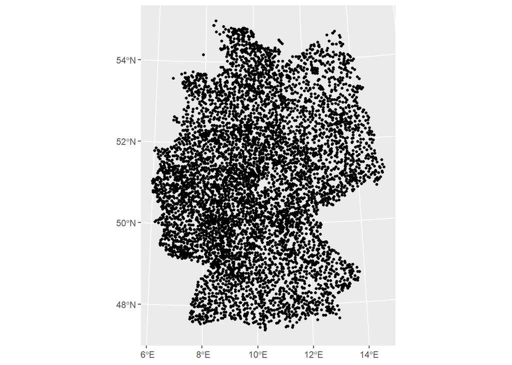

```r
station_sf %>%
  ggplot() + geom_sf(size=1)
```

Hier sieht man nun alle Jahresmelder über die gesamte Messzeit in der Datenbank.

Soll nur für Rheinland-Pfalz benutzt werden, muss wieder gefiltert werden:

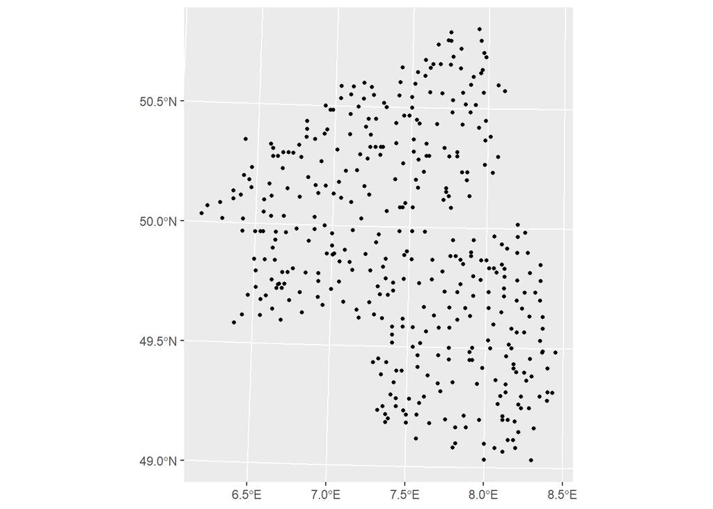

```r
station_sf %>%
  filter(bundesland=="Rheinland-Pfalz") %>%
  ggplot() + geom_sf(size=1)
```

oder auch mehrere Bundesländer:

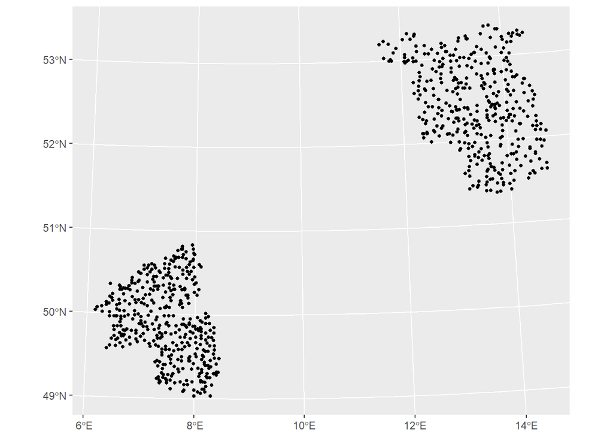

```r
station_sf %>%
  filter(bundesland %in% c("Rheinland-Pfalz","Brandenburg")) %>%
  ggplot() + geom_sf(size=1)
```

Wollen wir nur die aktuell aktiven Stationen sehen oder benutzen müssen wir nach Stationen schauen deren Auflösungsdatum nicht gesetzt ist also NA ist.

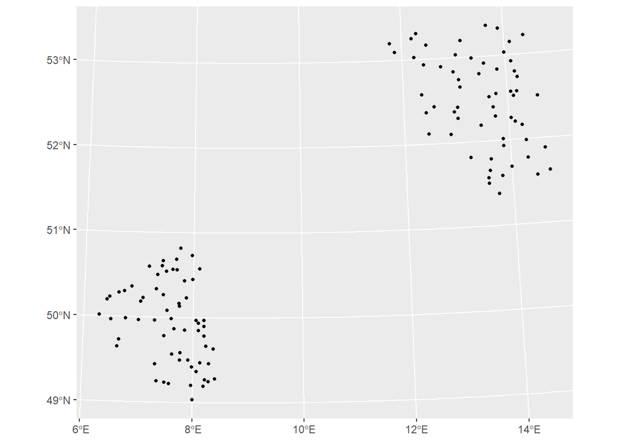

```r
aktive_melder_sf <- Stationen %>%
  collect() %>%
  station_df_to_sf() %>%
  filter(is.na(datum_stationsaufloesung))

aktive_melder_sf %>%
  filter(bundesland %in% c("Rheinland-Pfalz","Brandenburg")) %>%
  ggplot() + geom_sf(size=1)
```

oder Bundesweit

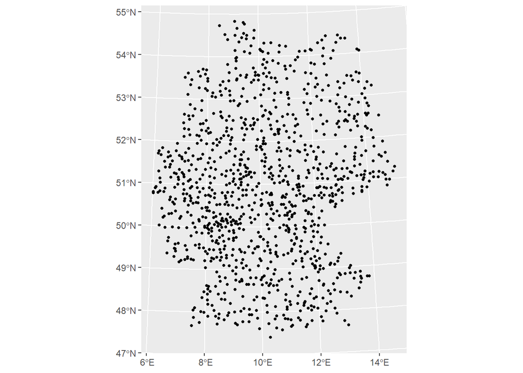

```r
Stationen %>%
  collect() %>%
  station_df_to_sf() %>%
  filter(is.na(datum_stationsaufloesung)) %>%
  ggplot() + geom_sf(size=1)
```

Möchte man Grenzen hinzu plotten ohne Datenzugehörigkeit kann man das inkludierte GeoPackage benutzen welches auch intern für Naturräume etc benutzt wird.

Einladen des Geopackages

```r
gfile <- "data/Naturraum_Grenzen_DE.gpkg"
sf::st_layers(gfile)
```

```
## Driver: GPKG
## Available layers:
##        layer_name geometry_type features fields
## 1      bundesland Multi Polygon       16      5
## 2       landkreis Multi Polygon      402      5
## 3    staatsgrenze Multi Polygon        1      2
## 4 naturraumgruppe Multi Polygon       86      3
## 5       naturraum Multi Polygon      516      3
```

Einladen der Layer

```r
bundesland_sf <- read_sf("data/Naturraum_Grenzen_DE.gpkg","bundesland")
nrg_sf <- read_sf("data/Naturraum_Grenzen_DE.gpkg","naturraumgruppe")
nr_sf <- read_sf("data/Naturraum_Grenzen_DE.gpkg","naturraum")
lk_sf <- read_sf("data/Naturraum_Grenzen_DE.gpkg","landkreis")
staatsgrenze_sf <- read_sf("data/Naturraum_Grenzen_DE.gpkg","staatsgrenze")
```

Hinzufügen der Grenze:

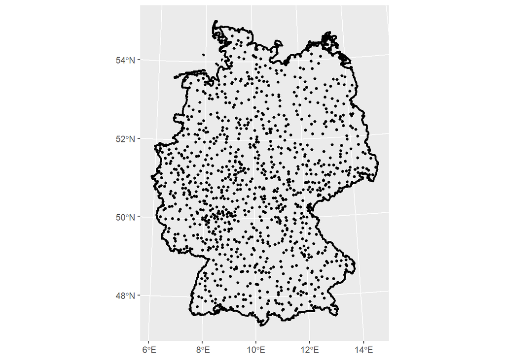

```r
Stationen %>%
  collect() %>%
  station_df_to_sf() %>%
  filter(is.na(datum_stationsaufloesung)) %>%
  ggplot() +
  geom_sf(size=1) +
  geom_sf(data=staatsgrenze_sf,show.legend = FALSE,size=1,color="black",fill=NA)
```

Entweder wir verschieben die Staatsgrenze nach oben:

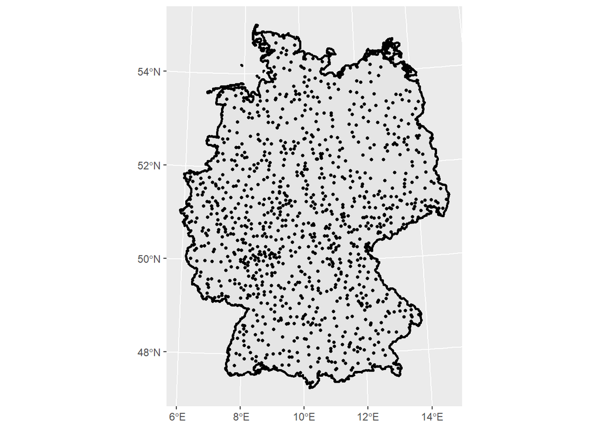

```r
Stationen %>%
  collect() %>%
  station_df_to_sf() %>%
  filter(is.na(datum_stationsaufloesung)) %>%
  ggplot() +
  geom_sf(data=staatsgrenze_sf,show.legend = FALSE,size=1,color="black") +
  geom_sf(size=1)
```

Oder wir setzen die Füllung auf NA , je nachdem was gewünscht ist und was dargestellt werden soll

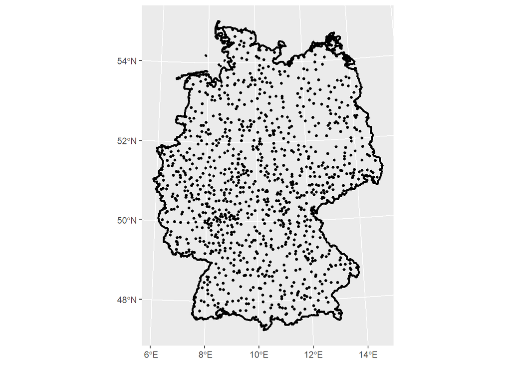

```r
Stationen %>%
  collect() %>%
  station_df_to_sf() %>%
  filter(is.na(datum_stationsaufloesung)) %>%
  ggplot() +
  geom_sf(size=1) +
  geom_sf(data=staatsgrenze_sf,show.legend = FALSE,size=1,color="black",fill=NA)
```

### Daten Verknüpfen

Berechnen wir den mittleren Julianischen Tag der Haselblühbeginn zwischen 1991 und 2021 nach Naturräumen gruppiert:

```r
Daten_rlp %>%
  filter(pflanze=="Hasel",refjahr>1990 & refjahr<2022) %>%
  group_by(naturraum_code) %>%
  summarize(mean_jultag=mean(jultag))
```

```
## # A tibble: 36 x 2
##    naturraum_code mean_jultag
##             <int>       <dbl>
##  1           1700        36.9
##  2           1710        37.0
##  3           1800        40.4
##  4           1920        44.9
##  5           1930        42.0
##  6           1940        49.0
##  7           1950        54.7
##  8           2200        31.3
##  9           2210        28.0
## 10           2270        36.5
## # ... with 26 more rows
```

Um dies nun als Karte darzustellen muessen wir die Daten wieder mit einer geometry darstellen:

```r
Daten_rlp %>%
  filter(pflanze=="Hasel",refjahr>1990 & refjahr<2022) %>%
  group_by(naturraum_code) %>%
  summarize(mean_jultag=mean(jultag)) %>%
  nr_df_to_sf(col2geom="naturraum_code",geomcol = "naturraum_code")
```

```
## # A tibble: 36 x 3
##    naturraum_code mean_jultag                                               geom
##             <int>       <dbl>                                 <MULTIPOLYGON [m]>
##  1           1700        36.9 (((429847.8 5492077, 430704.4 5491550, 431230.2 5~
##  2           1710        37.0 (((429478.7 5452745, 429134.9 5452360, 429149.8 5~
##  3           1800        40.4 (((400412.3 5474227, 400449.3 5473606, 400785.2 5~
##  4           1920        44.9 (((410233.5 5483190, 411229.1 5482926, 412145.7 5~
##  5           1930        42.0 (((394484.9 5518558, 394129 5517708, 394956.2 551~
##  6           1940        49.0 (((386036.2 5517555, 386411.1 5517380, 387435.6 5~
##  7           1950        54.7 (((384981.6 5521040, 387583.6 5521531, 389462.9 5~
##  8           2200        31.3 (((437834.6 5487549, 438763.2 5489610, 439939.7 5~
##  9           2210        28.0 (((453589.4 5522150, 453569.4 5520319, 453332.5 5~
## 10           2270        36.5 (((448537.5 5538042, 449204.3 5537685, 449866 553~
## # ... with 26 more rows
```

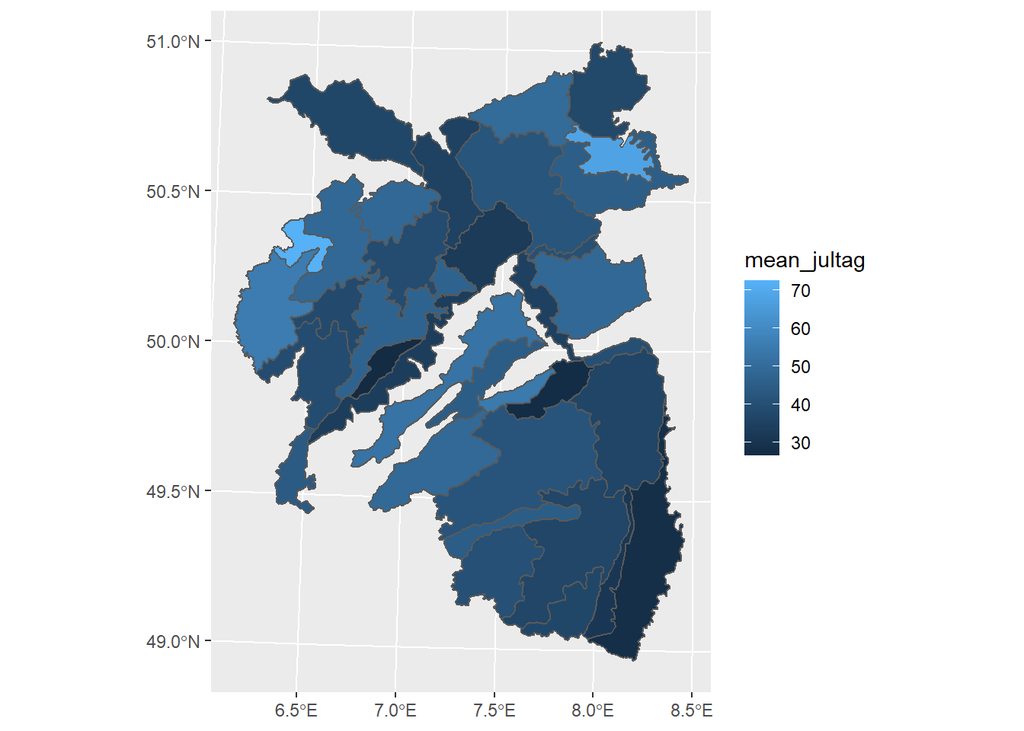

```r
Daten_rlp %>%
  filter(pflanze=="Hasel",refjahr>1990 & refjahr<2022) %>%
  group_by(naturraum_code) %>%
  summarize(mean_jultag=mean(jultag)) %>%
  nr_df_to_sf(col2geom="naturraum_code",geomcol = "naturraum_code") %>%
  ggplot() +
  geom_sf(aes(fill=mean_jultag,geometry=geom),show.legend = TRUE)
```

Um nur auf das Bundesland Rheinland-Pfalz zu clippen kann in der nr_df_to_sf das clip argument benutzt werden. Nimmt bisher nur Bundesländer an

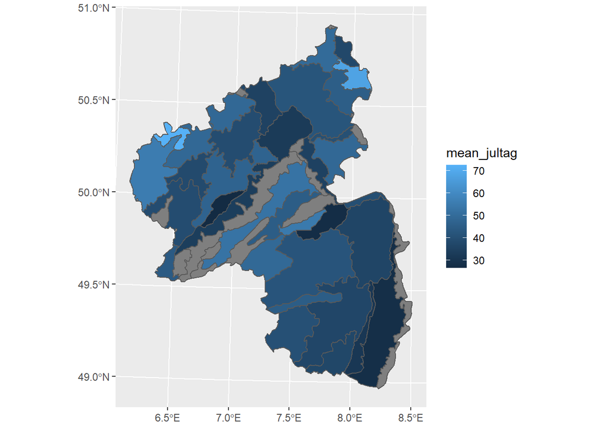

```r
Daten_rlp %>%
  filter(pflanze=="Hasel",refjahr>1990 & refjahr<2022) %>%
  group_by(naturraum_code) %>%
  summarize(mean_jultag=mean(jultag)) %>%
  nr_df_to_sf(col2geom="naturraum_code",geomcol = "naturraum_code",clip="Rheinland-Pfalz") %>%
  ggplot() +
  geom_sf(aes(fill=mean_jultag,geometry=geom),show.legend = TRUE)
```

Möchte man nun nach Natturraumgruppe die Daten darstellen wird natturaum_code zu naturraumgruppe_code geändert:

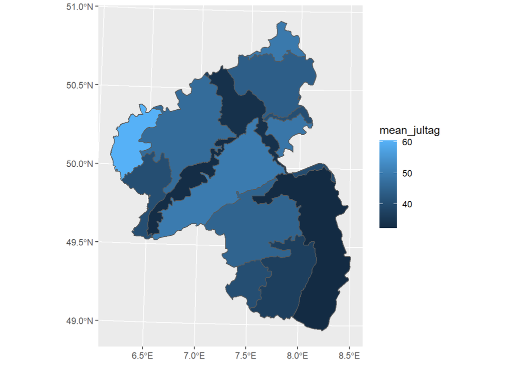

```r
Daten_rlp %>%
  filter(pflanze=="Hasel",refjahr>1990 & refjahr<2022) %>%
  group_by(naturraumgruppe_code) %>%
  summarize(mean_jultag=mean(jultag)) %>%
  nr_df_to_sf(col2geom="naturraumgruppe_code",geomcol = "naturraumgruppe_code",clip="Rheinland-Pfalz") %>%
  ggplot() +
  geom_sf(aes(fill=mean_jultag,geometry=geom),show.legend = TRUE)
```

Sollen die Melder hinzugefügt werden muss ein weiteres geom_sf() hinzugefügt werden mit eigenem datastream.

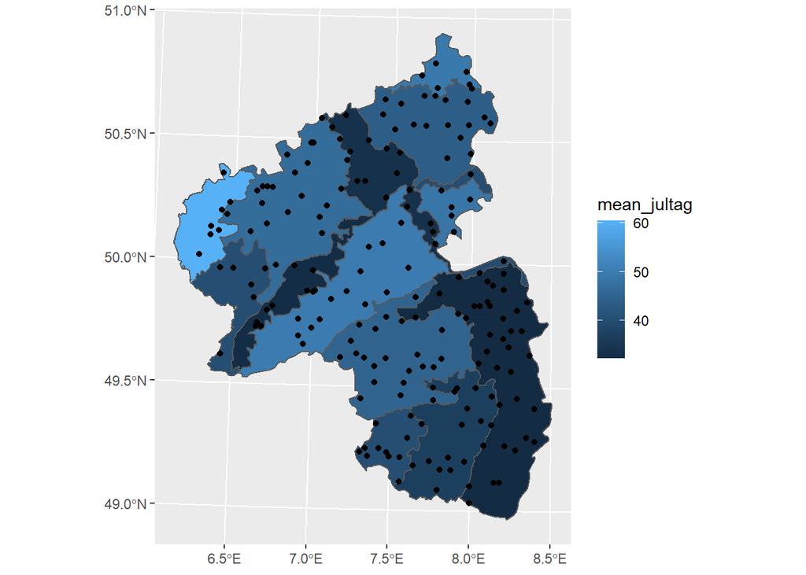

```r
Daten_rlp %>%
  filter(pflanze=="Hasel",refjahr>1990 & refjahr<2022) %>%
  group_by(naturraumgruppe_code) %>%
  summarize(mean_jultag=mean(jultag)) %>%
  nr_df_to_sf(col2geom="naturraumgruppe_code",geomcol = "naturraumgruppe_code",clip="Rheinland-Pfalz") %>%
  ggplot() +
  geom_sf(aes(fill=mean_jultag,geometry=geom),show.legend = TRUE) +
  geom_sf(data= Daten_rlp %>%
            filter(pflanze=="Hasel",refjahr>1990 & refjahr<2022) %>%
            station_df_to_sf())
```

Um sich nicht zu wiederholen können die gefilteren Daten in ein extra Objekt gespeichert werden. Da die Daten die in ggplot gepiped werden andere sind (naturraum) müssen die Stationsdaten extra generiert werden.

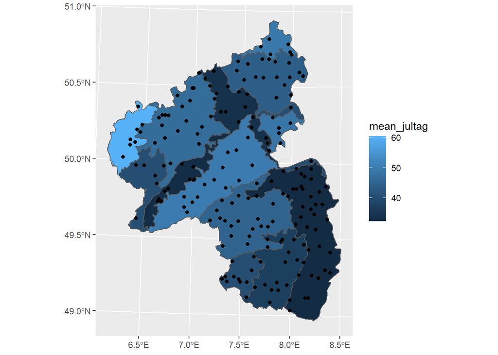

```r
datadf <- Daten_rlp %>%
  filter(pflanze=="Hasel",refjahr>1990 & refjahr<2022) %>%
  group_by(naturraumgruppe_code)

datadf %>%
  summarize(mean_jultag=mean(jultag)) %>%
  nr_df_to_sf(col2geom="naturraumgruppe_code",geomcol = "naturraumgruppe_code",clip="Rheinland-Pfalz") %>%
  ggplot() +
  geom_sf(aes(fill=mean_jultag,geometry=geom),show.legend = TRUE) +
  geom_sf(data= datadf %>%
            station_df_to_sf())
```

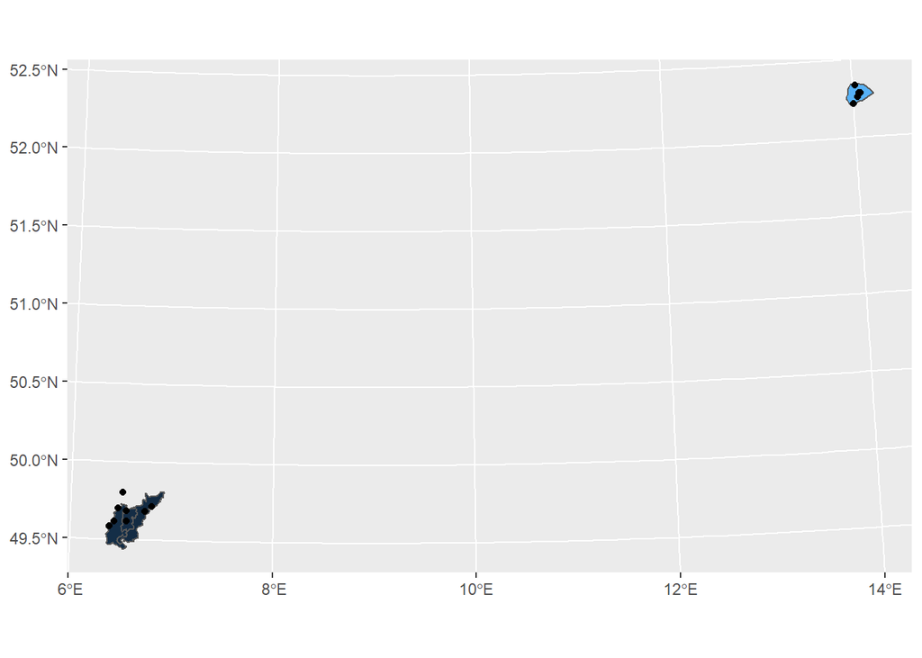

```r
megaframe_Jahresmelder <- tbl(con,"Megaframe_Jahresmelder")
bld <- c("Rheinland-Pfalz","Brandenburg")
datadf <- megaframe_Jahresmelder %>% filter(bundesland %in% bld & phase_id==5 & pflanze == "Hasel") %>%  collect() %>%
  filter(str_detect(naturraum,regex("saar",ignore_case = TRUE)))

datadf  %>%
  nr_df_to_sf(col2geom="naturraum_code",geomcol = "naturraum_code",clip=NULL) %>%
  ggplot() +
  geom_sf(aes(fill=naturraum_code,geometry=geom),show.legend = FALSE) +
  geom_sf(data= datadf %>%  station_df_to_sf() )
```

### Tabellen Header der vollen db 5 Zeilen, alle spalten

```r
dbListTables(con)
```

```
##  [1] "Daten_Jahresmelder"
##  [2] "Daten_Sofortmelder"
##  [3] "Mais_Spezifizierung"
##  [4] "Megaframe_Allemelder"
##  [5] "Megaframe_Jahresmelder"
##  [6] "Megaframe_Sofortmelder"
##  [7] "Notizen"
##  [8] "Obst_Spezifizierung"
##  [9] "Pflanze"
## [10] "Phaenologie_Besonderheiten_Zeitreihen"
## [11] "Phaenologie_Qualitaetsbyte"
## [12] "Phaenologie_Qualitaetsniveau"
## [13] "Phase"
## [14] "Phasendefinition"
## [15] "Phasendefinition_Jahresmelder"
## [16] "Phasendefinition_Sofortmelder"
## [17] "Ruebe_Spezifizierung"
## [18] "Spezifizierung_Notizen"
## [19] "Stationen"
## [20] "Stationen_Jahresmelder"
## [21] "Stationen_Sofortmelder"
## [22] "Weinrebe_Spezifizierung"
## [23] "sqlite_stat1"
## [24] "sqlite_stat4"
```

```r
tbl(con,"Daten_Jahresmelder") %>% print(n=5,width=Inf)
```

```
## # Source:   table<Daten_Jahresmelder> [?? x 8]
## # Database: sqlite 3.35.5 [D:\rphaeno\data\fulldb.sqlite3]
##   stations_id refjahr qualitaetsniveau pflanze_id phase_id eintrittsdatum
##         <int>   <int>            <int>      <int>    <int>          <int>
## 1           3    1953                7        201       25       19530523
## 2           3    1955                7        201       25       19550603
## 3           3    1975               10        201       25       19750607
## 4           3    1976               10        201       25       19760611
## 5           3    1977               10        201       25       19770531
##   eintrittsdatum_qb jultag
##               <int>  <int>
## 1                 1    143
## 2                 1    154
## 3                 1    158
## 4                 1    162
## 5                 1    151
## # ... with more rows
```

```r
tbl(con,"Megaframe_Jahresmelder") %>% print(n=5,width=Inf)
```

```
## # Source:   table<Megaframe_Jahresmelder> [?? x 26]
## # Database: sqlite 3.35.5 [D:\rphaeno\data\fulldb.sqlite3]
##   stations_id refjahr qualitaetsniveau pflanze_id phase_id eintrittsdatum
##         <int>   <int>            <int>      <int>    <int>          <int>
## 1           3    1953                7        201       25       19530523
## 2           3    1955                7        201       25       19550603
## 3           3    1975               10        201       25       19750607
## 4           3    1976               10        201       25       19760611
## 5           3    1977               10        201       25       19770531
##   eintrittsdatum_qb jultag stationsname   lat   lon stationshoehe
##               <int>  <int> <chr>        <dbl> <dbl>         <int>
## 1                 1    143 Aachen        50.8  6.09           202
## 2                 1    154 Aachen        50.8  6.09           202
## 3                 1    158 Aachen        50.8  6.09           202
## 4                 1    162 Aachen        50.8  6.09           202
## 5                 1    151 Aachen        50.8  6.09           202
##   naturraumgruppe_code naturraumgruppe naturraum_code naturraum
##                  <int> <chr>                    <int> <chr>
## 1                   56 Vennvorland               5610 Aachener Hügelland
## 2                   56 Vennvorland               5610 Aachener Hügelland
## 3                   56 Vennvorland               5610 Aachener Hügelland
## 4                   56 Vennvorland               5610 Aachener Hügelland
## 5                   56 Vennvorland               5610 Aachener Hügelland
##   datum_stationsaufloesung bundesland          pflanze       phase
##   <chr>                    <chr>               <chr>         <chr>
## 1 27.02.2011               Nordrhein-Westfalen Dauergrünland 1. Heuschnitt
## 2 27.02.2011               Nordrhein-Westfalen Dauergrünland 1. Heuschnitt
## 3 27.02.2011               Nordrhein-Westfalen Dauergrünland 1. Heuschnitt
## 4 27.02.2011               Nordrhein-Westfalen Dauergrünland 1. Heuschnitt
## 5 27.02.2011               Nordrhein-Westfalen Dauergrünland 1. Heuschnitt
##   phasendefinition
##   <chr>
## 1 im Beobachtungsgebiet wird erstmals Grünland zur Trockenfuttergewinnung gesch~
## 2 im Beobachtungsgebiet wird erstmals Grünland zur Trockenfuttergewinnung gesch~
## 3 im Beobachtungsgebiet wird erstmals Grünland zur Trockenfuttergewinnung gesch~
## 4 im Beobachtungsgebiet wird erstmals Grünland zur Trockenfuttergewinnung gesch~
## 5 im Beobachtungsgebiet wird erstmals Grünland zur Trockenfuttergewinnung gesch~
##   bbch_code hinweis_bbch             phase_englisch    pflanze_englisch
##       <int> <chr>                    <chr>             <chr>
## 1        NA kein BBCH-Code vorhanden first cut for hay meadows
## 2        NA kein BBCH-Code vorhanden first cut for hay meadows
## 3        NA kein BBCH-Code vorhanden first cut for hay meadows
## 4        NA kein BBCH-Code vorhanden first cut for hay meadows
## 5        NA kein BBCH-Code vorhanden first cut for hay meadows
##   pflanze_latein
##   <chr>
## 1 ----------
## 2 ----------
## 3 ----------
## 4 ----------
## 5 ----------
## # ... with more rows
```

```r
tbl(con,"Stationen") %>% print(n=5,width=Inf)
```

```
## # Source:   table<Stationen> [?? x 12]
## # Database: sqlite 3.35.5 [D:\rphaeno\data\fulldb.sqlite3]
##   stations_id stationsname   lat   lon stationshoehe naturraumgruppe_code
##         <int> <chr>        <dbl> <dbl>         <int>                <int>
## 1           3 Aachen        50.8  6.09           202                   56
## 2          98 Altastenberg  51.2  8.47           780                   33
## 3         140 Altmersleben  52.7 11.4             35                   86
## 4         183 Arkona        54.7 13.4             42                   71
## 5         198 Artern        51.4 11.3            164                   48
##   naturraumgruppe                             naturraum_code
##   <chr>                                                <int>
## 1 Vennvorland                                           5610
## 2 Bergisch-Sauerländisches Gebirge                      3330
## 3 Altmark                                               8620
## 4 Mecklenburgisch-Vorpommersches Küstengebiet           7140
## 5 Thüringer Becken und Randplatten Nrg 48               4870
##   naturraum                             datum_stationsaufloesung
##   <chr>                                 <chr>
## 1 Aachener Hügelland                    27.02.2011
## 2 Hochsauerland (Rothaargebirge)        06.12.1954
## 3 Stendaler Land                        31.12.2019
## 4 Höhen- und Binnenbodden von Nordrügen 31.12.2020
## 5 Helme-Unstrut-Niederung               31.12.2017
##   bundesland             melder
##   <chr>                  <chr>
## 1 Nordrhein-Westfalen    Jahresmelder
## 2 Nordrhein-Westfalen    Jahresmelder
## 3 Sachsen-Anhalt         Beides
## 4 Mecklenburg-Vorpommern Beides
## 5 Thüringen              Beides
## # ... with more rows
```

```r
tbl(con,"Pflanze") %>% print(n=5,width=Inf)
```

```
## # Source:   table<Pflanze> [?? x 4]
## # Database: sqlite 3.35.5 [D:\rphaeno\data\fulldb.sqlite3]
##   pflanze_id pflanze           pflanze_englisch pflanze_latein
##        <int> <chr>             <chr>            <chr>
## 1         25 Rüben             beet             Beta vulgaris
## 2        101 Beifuß            common wormwood  Artemisia vulgaris
## 3        102 Busch-Windröschen wood anemone     Anemone nemorosa
## 4        103 Eberesche         rowan            Sorbus aucuparia
## 5        104 Esche             ash              Fraxinus excelsior
## # ... with more rows
```

```r
tbl(con,"Phasendefinition") %>% print(n=5,width=Inf)
```

```
## # Source:   table<Phasendefinition> [?? x 7]
## # Database: sqlite 3.35.5 [D:\rphaeno\data\fulldb.sqlite3]
##   pflanze_id pflanze       phase_id phase
##        <int> <chr>            <int> <chr>
## 1        201 Dauergrünland        1 Ergrünen Beginn
## 2        201 Dauergrünland       25 1. Heuschnitt
## 3        201 Dauergrünland       26 1. Silageschnitt
## 4        201 Dauergrünland       27 2. Heuschnitt
## 5        201 Dauergrünland       28 2. Silageschnitt
##   phasendefinition
##   <chr>
## 1 etwa 25% der ausgewählten Dauergrünlandfläche zeit frisches Grün, d.h.  hat m~
## 2 im Beobachtungsgebiet wird erstmals Grünland zur Trockenfuttergewinnung gesch~
## 3 im Beobachtungsgebiet wird erstmals Grünland für Silage geschnitten
## 4 im Beobachtungsgebiet wird zum zweiten Mal in der Vegetationsperiode Grünland~
## 5 im Beobachtungsgebiet wird zum zweiten Mal in der Vegetationsperiode Grünland~
##   bbch_code hinweis_bbch
##       <int> <chr>
## 1        NA kein BBCH-Code vorhanden
## 2        NA kein BBCH-Code vorhanden
## 3        NA kein BBCH-Code vorhanden
## 4        NA <NA>
## 5        NA <NA>
## # ... with more rows
```

```r
tbl(con,"Mais_Spezifizierung") %>% print(n=5,width=Inf)
```

```
## # Source:   table<Mais_Spezifizierung> [?? x 10]
## # Database: sqlite 3.35.5 [D:\rphaeno\data\fulldb.sqlite3]
##   stations_id referenzjahr pflanze_id pflanze sorte_id
##         <int>        <int>      <int> <chr>      <int>
## 1         140         1987        215 Mais       20000
## 2         140         1988        215 Mais       20000
## 3         140         1990        215 Mais       20000
## 4         140         1992        215 Mais       20009
## 5         140         1993        215 Mais       20009
##   sorte                            ernteverfahren_id ernteverfahren
##   <chr>                                        <int> <chr>
## 1 Mais, Sorte unbekannt                            5 Silo-Ernte
## 2 Mais, Sorte unbekannt                            5 Silo-Ernte
## 3 Mais, Sorte unbekannt                            5 Silo-Ernte
## 4 Mais, mittelfrühe Reife, FAO 250                 5 Silo-Ernte
## 5 Mais, mittelfrühe Reife, FAO 250                 5 Silo-Ernte
##   siloreifezahl koernerreifezahl
##           <int>            <int>
## 1            NA               NA
## 2            NA               NA
## 3            NA               NA
## 4            NA               NA
## 5            NA               NA
## # ... with more rows
```

```r
tbl(con,"Weinrebe_Spezifizierung") %>% print(n=5,width=Inf)
```

```
## # Source:   table<Weinrebe_Spezifizierung> [?? x 13]
## # Database: sqlite 3.35.5 [D:\rphaeno\data\fulldb.sqlite3]
##   stations_id referenzjahr pflanze_id pflanze               sorte_id
##         <int>        <int>      <int> <chr>                    <int>
## 1        2034         2012        413 Weinrebe, späte Reife     4130
## 2        2034         2012        411 Weinrebe, frühe Reife     4110
## 3        2034         2013        413 Weinrebe, späte Reife     4130
## 4        2034         2013        411 Weinrebe, frühe Reife     4110
## 5        2034         2014        411 Weinrebe, frühe Reife     4110
##   sorte                                            ernteverfahren_id
##   <chr>                                                        <int>
## 1 Sorte unbekannt (bevorzugt Riesling/Scheurebe)                  10
## 2 Sorte unbekannt (bevorzugt Müller-Thurgau/Faber)                 8
## 3 Sorte unbekannt (bevorzugt Riesling/Scheurebe)                   8
## 4 Sorte unbekannt (bevorzugt Müller-Thurgau/Faber)                 8
## 5 Sorte unbekannt (bevorzugt Müller-Thurgau/Faber)                 8
##   ernteverfahren       parzelle_hoehe hangneigung_id hangneigung_beschreibung
##   <chr>                         <int>          <int> <chr>
## 1 Ernteverfahren unbek            200              3 mäßig geneigt, 10 - 14 Grad
## 2 Hauptlese                       200              3 mäßig geneigt, 10 - 14 Grad
## 3 Hauptlese                       200              3 mäßig geneigt, 10 - 14 Grad
## 4 Hauptlese                       200              3 mäßig geneigt, 10 - 14 Grad
## 5 Hauptlese                       200              3 mäßig geneigt, 10 - 14 Grad
##   hangrichtung_id hangrichtung_beschreibung
##             <int> <chr>
## 1               7 West
## 2               7 West
## 3               7 West
## 4               7 West
## 5               8 Nordwest
## # ... with more rows
```

```r
tbl(con,"Ruebe_Spezifizierung") %>% print(n=5,width=Inf)
```

```
## # Source:   table<Ruebe_Spezifizierung> [?? x 6]
## # Database: sqlite 3.35.5 [D:\rphaeno\data\fulldb.sqlite3]
##   stations_id referenz_jahr pflanze_id pflanze sorte_id sorte
##         <int>         <int>      <int> <chr>      <int> <chr>
## 1        1780          2020         25 Rüben        252 Futter-Rübe
## 2        4933          2017         25 Rüben        252 Futter-Rübe
## 3        4933          2018         25 Rüben        252 Futter-Rübe
## 4        4933          2019         25 Rüben        252 Futter-Rübe
## 5        4933          2020         25 Rüben        252 Futter-Rübe
## # ... with more rows
```

```r
tbl(con,"Phaenologie_Besonderheiten_Zeitreihen") %>% print(n=5,width=Inf)
```

```
## # Source:   table<Phaenologie_Besonderheiten_Zeitreihen> [?? x 7]
## # Database: sqlite 3.35.5 [D:\rphaeno\data\fulldb.sqlite3]
##   pflanze_id phase_id kurzbezeichnung         jahr_beginn jahr_ende
##        <int>    <int> <chr>                         <int>     <int>
## 1        201        1 Dauergrünland: Ergrünen        1991      1991
## 2        103        3 Eberesche: Austrieb            1991      1991
## 3        112        3 Hänge-Birke: Austrieb          1991      1991
## 4        122        3 Rosskastanie: Austrieb         1991      1991
## 5        310        3 Apfel: Austrieb                1991        NA
##   besonderheitenbeschreibung
##   <chr>
## 1 "ab 1991 neu im Beobachtungsprogramm, für Ostdeutschland konnte die Umstellun~
## 2 "ab 1991 neu im Beobachtungsprogramm, für Ostdeutschland konnte die Umstellun~
## 3 "ab 1991 neu im Beobachtungsprogramm, für Ostdeutschland konnte die Umstellun~
## 4 "ab 1991 neu im Beobachtungsprogramm, für Ostdeutschland konnte die Umstellun~
## 5 "Das zugehörige Pflückreifedatum wurde in der Datenprüfung als falsch deklari~
##   bemerkungen
##   <chr>
## 1 <NA>
## 2 <NA>
## 3 <NA>
## 4 <NA>
## 5 Die Zuordnung der Daten zu ph_objekt_id 310 erfolgt im Rahmen der Datenkorrek~
## # ... with more rows
```

```r
tbl(con,"Notizen") %>% print(n=5,width=Inf)
```

```
## # Source:   table<Notizen> [?? x 8]
## # Database: sqlite 3.35.5 [D:\rphaeno\data\fulldb.sqlite3]
##   stations_id refjahr      qualitaetsniveau pflanze_id pflanze      phase_id
##   <chr>       <chr>        <chr>            <chr>      <chr>        <chr>
## 1 STATIONS_ID REFERENZJAHR QUALITAETSNIVEAU OBJEKT_ID  OBJEKT       PHASE_ID
## 2 1684        1974         10               253        Zucker-Rübe  10
## 3 3158        1982         10               202        Winterweizen 10
## 4 3158        1982         10               202        Winterweizen 21
## 5 3158        1982         10               202        Winterweizen 22
##   phase             notizen
##   <chr>             <chr>
## 1 PHASE             NOTIZEN
## 2 Bestellung Beginn 2. Bestellung, weil Zuckerrüben am 14.04. erfroren
## 3 Bestellung Beginn Daten vom Bundessortenamt
## 4 Gelbreife Beginn  Daten vom Bundessortenamt
## 5 Vollreife Beginn  Daten vom Bundessortenamt
## # ... with more rows
```